# Final Project Analysis

Joy Y Kim

2025-05-09

# Introduction

## Dataset Description

This is a statistical analysis of the dataset titled “Student Habits vs Academic Performance: A Simulated Study”, as found on Kaggle (https://www.kaggle.com/datasets/jayaantanaath/student-habits-vs-academic-performance?resource=download). The dataset features 1,000 student records, where each row represents an individual student. The data captures the following variables:

- age: age in years
- gender: female, male, or other
- study_hours_per_day: daily study time in hours
- social_media_hours: daily social media usage in hours
- netflix_hours: daily Netflix usage in hours
- part_time_job: if the student holds a part time job (Yes or No)
- attendance_percentage: percentage student attended school
- sleep_hours: daily sleep time in hours
- diet_quality: diet quality (Poor, Fair, or Good)
- exercise_frequency: frequency of exercise per week (0-6 days per week)
- parental_education_level: highest level of education student’s parents have attained (None, High School, Bachelor, Master)
- internet_quality: quality of student’s Internet (Poor, Average, Good)
- mental_health_rating: rating of student’s mental health on a scale of 1-10
- extracurricular_participation: if the student participates in extracurricular activities (Yes or No)
- exam_score: final exam score on a scale of 0-100

## Problem Statement

This analysis aims to examine the extent to which demographic, lifestyle, academic, and environmental factors jointly relate to final exam scores among students.

# Methodology

The overall methodology used for this statistical analysis is linear regression. The following steps are outlined as followd:

1. Data cleaning and preprocessing
2. Summary statistics of variables and visualization of distributions and relationships
3. Variable selection and hypothesis testing
4. Model performance assessment
5. Model validation
6. Verification of linear regression assumptions
7. Handling of assumption violations
8. Feature impact analysis and interpretation

## Exploratory Data Analysis

```r
# Load the dataset
studentData <- read.csv("Data/student_habits_performance.csv")
names(studentData)
```

```
##  [1] "student_id"                    "age"
##  [3] "gender"                        "study_hours_per_day"
##  [5] "social_media_hours"            "netflix_hours"
##  [7] "part_time_job"                 "attendance_percentage"
##  [9] "sleep_hours"                   "diet_quality"
## [11] "exercise_frequency"            "parental_education_level"
## [13] "internet_quality"              "mental_health_rating"
## [15] "extracurricular_participation" "exam_score"
```

```r
dim(studentData)
```

```
## [1] 1000   16
```

## Data Cleaning and Preprocessing Steps

```r
str(studentData)
```

```
## 'data.frame':    1000 obs. of  16 variables:
##  $ student_id                   : chr  "S1000" "S1001" "S1002" "S1003" ...
##  $ age                          : int  23 20 21 23 19 24 21 21 23 18 ...
##  $ gender                       : chr  "Female" "Female" "Male" "Female" ...
##  $ study_hours_per_day          : num  0 6.9 1.4 1 5 7.2 5.6 4.3 4.4 4.8 ...
##  $ social_media_hours           : num  1.2 2.8 3.1 3.9 4.4 1.3 1.5 1 2.2 3.1 ...
##  $ netflix_hours                : num  1.1 2.3 1.3 1 0.5 0 1.4 2 1.7 1.3 ...
##  $ part_time_job                : chr  "No" "No" "No" "No" ...
##  $ attendance_percentage        : num  85 97.3 94.8 71 90.9 82.9 85.8 77.7 100 95.4 ...
##  $ sleep_hours                  : num  8 4.6 8 9.2 4.9 7.4 6.5 4.6 7.1 7.5 ...
##  $ diet_quality                 : chr  "Fair" "Good" "Poor" "Poor" ...
##  $ exercise_frequency           : int  6 6 1 4 3 1 2 0 3 5 ...
##  $ parental_education_level     : chr  "Master" "High School" "High School" "Master" ...
##  $ internet_quality             : chr  "Average" "Average" "Poor" "Good" ...
##  $ mental_health_rating         : int  8 8 1 1 1 4 4 8 1 10 ...
##  $ extracurricular_participation: chr  "Yes" "No" "No" "Yes" ...
##  $ exam_score                   : num  56.2 100 34.3 26.8 66.4 100 89.8 72.6 78.9 100 ...
```

```r
# Convert categorical variables to factors
studentData$gender <- as.factor(studentData$gender)
studentData$part_time_job <- as.factor(studentData$part_time_job)
studentData$diet_quality <- as.factor(studentData$diet_quality)
studentData$parental_education_level <- as.factor(studentData$parental_education_level)
studentData$internet_quality <- as.factor(studentData$internet_quality)
studentData$extracurricular_participation <- as.factor(studentData$extracurricular_participation)

#remove first column
studentData <- studentData[ , -1]
```

## Identification of Missing Values and Outliers

```r
# Identification of missing values
colSums(is.na(studentData)) #no missing values
```

```
##                           age                        gender
##                             0                             0
##           study_hours_per_day            social_media_hours
##                             0                             0
##                 netflix_hours                 part_time_job
##                             0                             0
##         attendance_percentage                   sleep_hours
##                             0                             0
##                  diet_quality            exercise_frequency
##                             0                             0
##      parental_education_level              internet_quality
##                             0                             0
##          mental_health_rating extracurricular_participation
##                             0                             0
##                    exam_score
##                             0
```

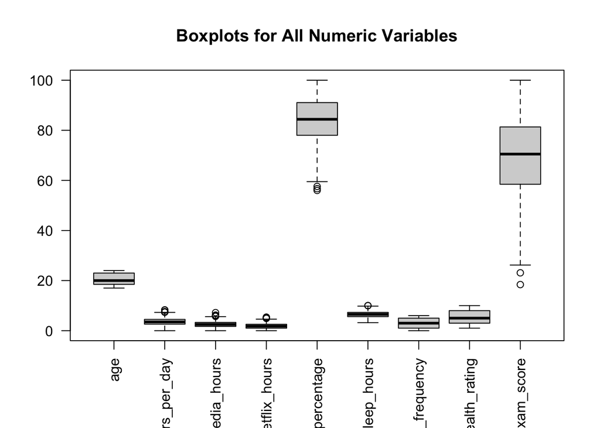

```r
# Identification of outliers
numeric_vars <- studentData[sapply(studentData, is.numeric)]

# Boxplots for all numeric variables
boxplot(numeric_vars, main = "Boxplots for All Numeric Variables", las = 2)
```

## Summary Statistics of Variables

```r
summary(studentData)
```

```
##       age           gender    study_hours_per_day social_media_hours
##  Min.   :17.00   Female:481   Min.   :0.00        Min.   :0.000
##  1st Qu.:18.75   Male  :477   1st Qu.:2.60        1st Qu.:1.700
##  Median :20.00   Other : 42   Median :3.50        Median :2.500
##  Mean   :20.50                Mean   :3.55        Mean   :2.506
##  3rd Qu.:23.00                3rd Qu.:4.50        3rd Qu.:3.300
##  Max.   :24.00                Max.   :8.30        Max.   :7.200
##  netflix_hours   part_time_job attendance_percentage  sleep_hours
##  Min.   :0.000   No :785       Min.   : 56.00        Min.   : 3.20
##  1st Qu.:1.000   Yes:215       1st Qu.: 78.00        1st Qu.: 5.60
##  Median :1.800                 Median : 84.40        Median : 6.50
##  Mean   :1.820                 Mean   : 84.13        Mean   : 6.47
##  3rd Qu.:2.525                 3rd Qu.: 91.03        3rd Qu.: 7.30
##  Max.   :5.400                 Max.   :100.00        Max.   :10.00
##  diet_quality exercise_frequency parental_education_level internet_quality
##  Fair:437     Min.   :0.000      Bachelor   :350          Average:391
##  Good:378     1st Qu.:1.000      High School:392          Good   :447
##  Poor:185     Median :3.000      Master     :167          Poor   :162
##               Mean   :3.042      None       : 91
##               3rd Qu.:5.000
##               Max.   :6.000
##  mental_health_rating extracurricular_participation   exam_score
##  Min.   : 1.000       No :682                       Min.   : 18.40
##  1st Qu.: 3.000       Yes:318                       1st Qu.: 58.48
##  Median : 5.000                                     Median : 70.50
##  Mean   : 5.438                                     Mean   : 69.60
##  3rd Qu.: 8.000                                     3rd Qu.: 81.33
##  Max.   :10.000                                     Max.   :100.00
```

## Visualization of Distributions and Relationships

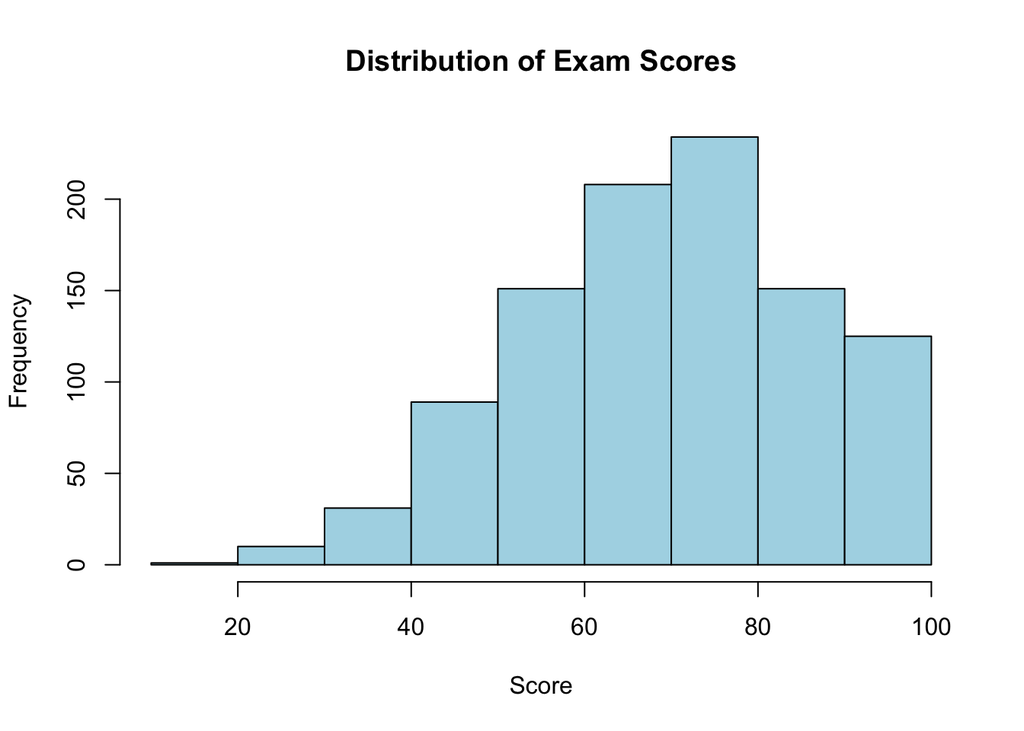

```r
#histograms of numerical variables

hist(studentData$exam_score, main = "Distribution of Exam Scores", xlab = "Score", col = "lightblue")
```

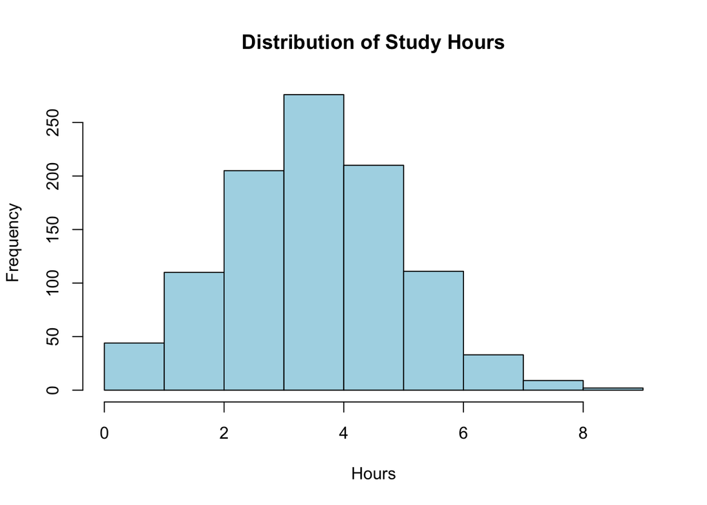

```r
hist(studentData$study_hours_per_day, main = "Distribution of Study Hours", xlab = "Hours", col = "lightblue")
```

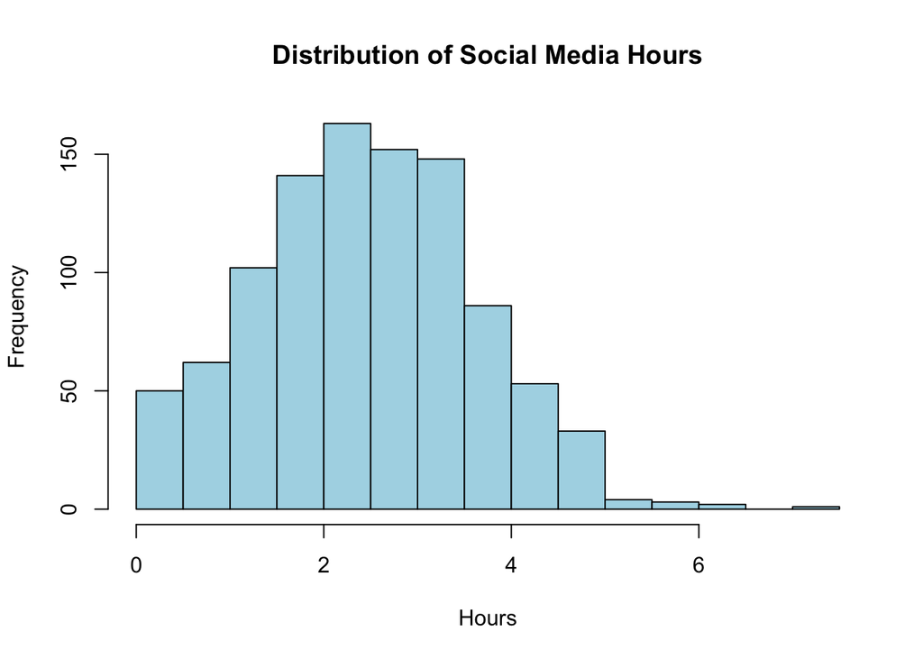

```r
hist(studentData$social_media_hours, main = "Distribution of Social Media Hours", xlab = "Hours", col = "lightblue")
```

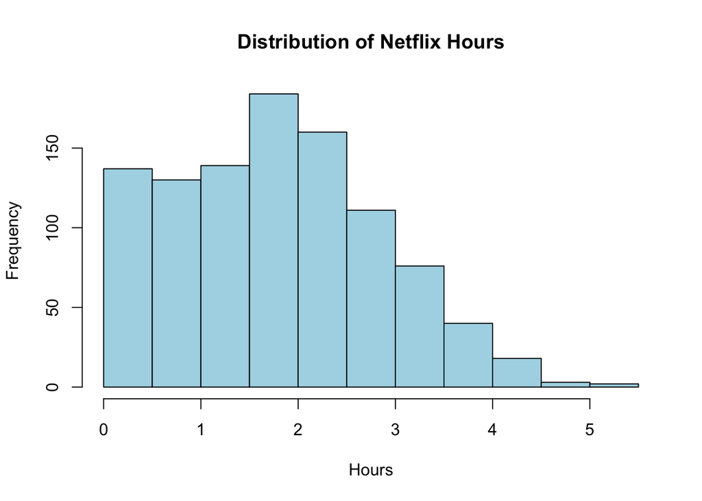

```r
hist(studentData$netflix_hours, main = "Distribution of Netflix Hours", xlab = "Hours", col = "lightblue")
```

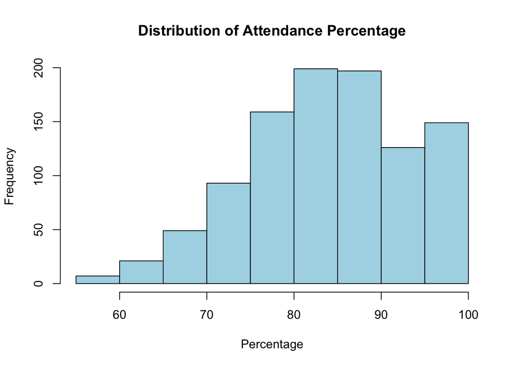

```r
hist(studentData$attendance_percentage, main = "Distribution of Attendance Percentage", xlab = "Percentage", col = "lightblue")
```

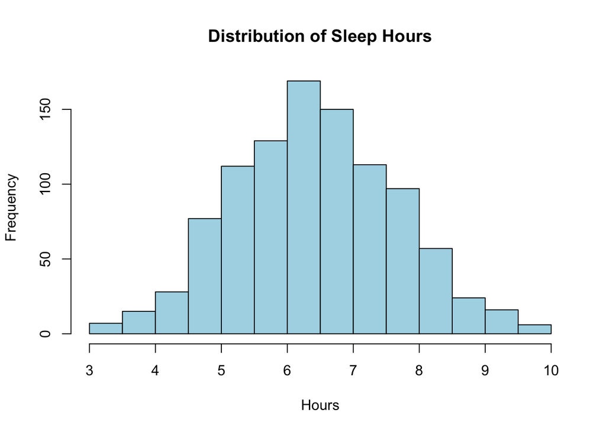

```r
hist(studentData$sleep_hours, main = "Distribution of Sleep Hours", xlab = "Hours", col = "lightblue")
```

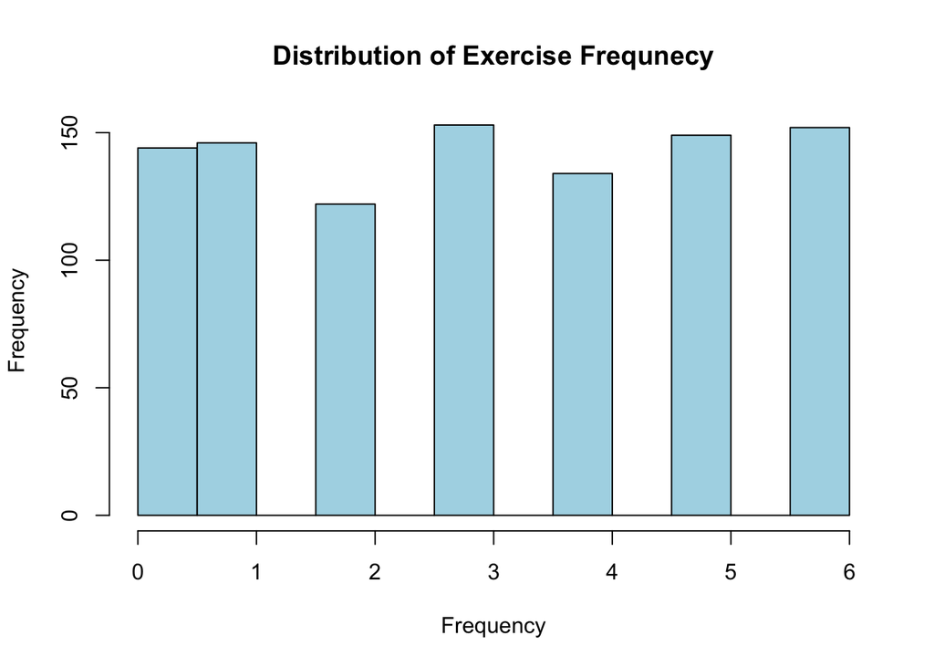

```r
hist(studentData$exercise_frequency, main = "Distribution of Exercise Frequnecy", xlab = "Frequency", col = "lightblue")
```

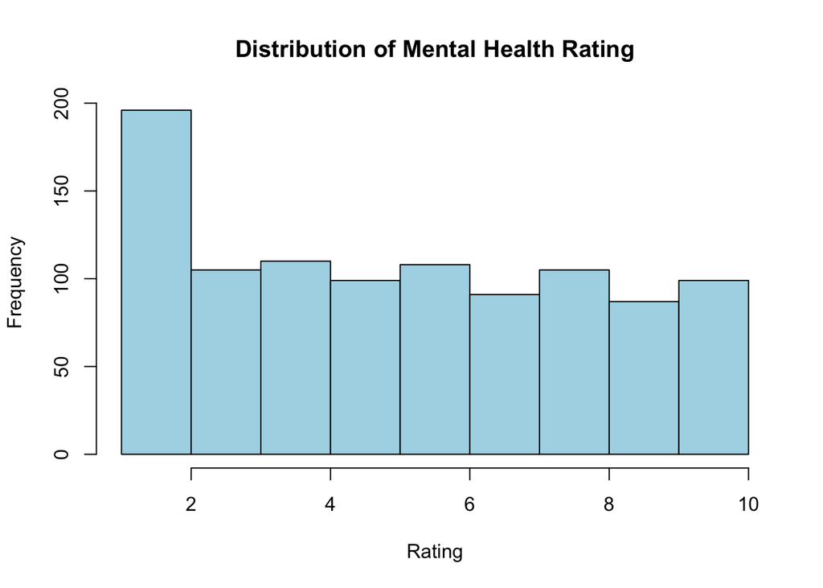

```r
hist(studentData$mental_health_rating, main = "Distribution of Mental Health Rating", xlab = "Rating", col = "lightblue")
```

# Analysis

## Variable Selection & Hypothesis Testing

I will be implementing three different variable selection techniques: forward selection, backward selection, and the branch and bound method. The branch and bound method is feasible as the number of predictors is 14. I did, however, want to compare this method to the more computationally efficient stepwise selection methods as well.

```r
# Variable selection technique 1: Forward selection

## smallest model to consider
intOnly <- lm(exam_score~ 1, data = studentData)

## largest model to consider
fullmod <- lm(exam_score ~ ., data = studentData)

out_forward_bic <- step(object = intOnly, direction = "forward",
                        scope = formula(fullmod), trace = T, k = log(nrow(studentData)))
```

```
## Start:  AIC=5659.18
## exam_score ~ 1
##
##                                 Df Sum of Sq    RSS    AIC
## + study_hours_per_day            1    194133  90805 4522.5
## + mental_health_rating           1     29456 255482 5557.0
## + netflix_hours                  1      8408 276530 5636.1
## + social_media_hours             1      7921 277017 5637.9
## + exercise_frequency             1      7304 277634 5640.1
## + sleep_hours                    1      4219 280719 5651.2
## + attendance_percentage          1      2300 282639 5658.0
## <none>                                       284938 5659.2
## + part_time_job                  1       202 284737 5665.4
## + age                            1        23 284916 5666.0
## + extracurricular_participation  1         0 284938 5666.1
## + internet_quality               2       834 284105 5670.1
## + diet_quality                   2       722 284216 5670.5
## + gender                         2        81 284857 5672.7
## + parental_education_level       3       559 284379 5677.9
##
## Step:  AIC=4522.53
## exam_score ~ study_hours_per_day
##
##                                 Df Sum of Sq   RSS    AIC
## + mental_health_rating           1   30029.1 60776 4127.9
## + exercise_frequency             1    9633.6 81172 4417.3
## + social_media_hours             1    9595.8 81210 4417.8
## + netflix_hours                  1    6084.7 84721 4460.1
## + sleep_hours                    1    5961.9 84843 4461.5
## + attendance_percentage          1    1324.5 89481 4514.7
## <none>                                       90805 4522.5
## + internet_quality               2     778.3 90027 4527.7
## + age                            1      42.3 90763 4529.0
## + extracurricular_participation  1       3.6 90802 4529.4
## + part_time_job                  1       1.9 90804 4529.4
## + parental_education_level       3    1000.0 89805 4532.2
## + diet_quality                   2      55.0 90750 4535.7
## + gender                         2      33.9 90771 4536.0
##
## Step:  AIC=4127.92
```

[output cut: 80 more lines]

```
## + parental_education_level       3     56.76 29975 3469.5
##
## Step:  AIC=3394.18
## exam_score ~ study_hours_per_day + mental_health_rating + social_media_hours +
##     exercise_frequency + sleep_hours + netflix_hours + attendance_percentage
##
##                                 Df Sum of Sq   RSS    AIC
## <none>                                       28189 3394.2
## + part_time_job                  1     8.027 28181 3400.8
## + age                            1     1.052 28188 3401.1
## + extracurricular_participation  1     0.095 28189 3401.1
## + diet_quality                   2    94.989 28094 3404.6
## + internet_quality               2    51.881 28137 3406.2
## + gender                         2    22.966 28166 3407.2
## + parental_education_level       3    40.419 28148 3413.5
```

```r
# Model summary and assess model performance with metrics
summary(out_forward_bic)
```

```
##
## Call:
## lm(formula = exam_score ~ study_hours_per_day + mental_health_rating +
##     social_media_hours + exercise_frequency + sleep_hours + netflix_hours +
##     attendance_percentage, data = studentData)
##
## Residuals:
##      Min       1Q   Median       3Q      Max
## -21.9509  -3.3953  -0.0283   3.6680  15.9059
##
## Coefficients:
##                       Estimate Std. Error t value Pr(>|t|)
## (Intercept)            6.15722    1.89252   3.253  0.00118 **
## study_hours_per_day    9.57456    0.11503  83.238  < 2e-16 ***
## mental_health_rating   1.94891    0.05924  32.897  < 2e-16 ***
## social_media_hours    -2.61978    0.14413 -18.177  < 2e-16 ***
## exercise_frequency     1.45187    0.08338  17.413  < 2e-16 ***
## sleep_hours            2.00462    0.13764  14.564  < 2e-16 ***
## netflix_hours         -2.27708    0.15697 -14.507  < 2e-16 ***
## attendance_percentage  0.14473    0.01797   8.054 2.28e-15 ***
## ---
## Signif. codes:  0 '***' 0.001 '**' 0.01 '*' 0.05 '.' 0.1 ' ' 1
##
## Residual standard error: 5.331 on 992 degrees of freedom
## Multiple R-squared:  0.9011, Adjusted R-squared:  0.9004
## F-statistic:  1291 on 7 and 992 DF,  p-value: < 2.2e-16
```

```r
# Variable selection technique 2: Backward selection

out_backward_bic <- step(object = fullmod, direction = "backward",
                        scope = formula(fullmod), trace = T, k = log(nrow(studentData)))
```

```
## Start:  AIC=3469.22
## exam_score ~ age + gender + study_hours_per_day + social_media_hours +
##     netflix_hours + part_time_job + attendance_percentage + sleep_hours +
##     diet_quality + exercise_frequency + parental_education_level +
##     internet_quality + mental_health_rating + extracurricular_participation
##
##                                 Df Sum of Sq    RSS    AIC
## - parental_education_level       3        44  28012 3450.1
## - gender                         2        26  27994 3456.3
## - internet_quality               2        50  28018 3457.2
## - diet_quality                   2        94  28062 3458.7
## - extracurricular_participation  1         0  27968 3462.3
## - age                            1         1  27969 3462.3
## - part_time_job                  1         7  27975 3462.6
## <none>                                        27968 3469.2
## - attendance_percentage          1      1770  29738 3523.7
## - sleep_hours                    1      5906  33874 3653.9
## - netflix_hours                  1      5968  33936 3655.7
## - exercise_frequency             1      8510  36478 3727.9
## - social_media_hours             1      9205  37173 3746.8
## - mental_health_rating           1     29934  57902 4190.0
## - study_hours_per_day            1    195185 223153 5539.1
##
## Step:  AIC=3450.07
## exam_score ~ age + gender + study_hours_per_day + social_media_hours +
##     netflix_hours + part_time_job + attendance_percentage + sleep_hours +
##     diet_quality + exercise_frequency + internet_quality + mental_health_rating +
##     extracurricular_participation
##
##                                 Df Sum of Sq    RSS    AIC
## - gender                         2        23  28035 3437.1
## - internet_quality               2        49  28061 3438.0
## - diet_quality                   2        93  28106 3439.6
## - extracurricular_participation  1         0  28012 3443.2
## - age                            1         1  28013 3443.2
## - part_time_job                  1         7  28019 3443.4
## <none>                                        28012 3450.1
## - attendance_percentage          1      1784  29796 3504.9
## - sleep_hours                    1      5934  33946 3635.3
## - netflix_hours                  1      5948  33960 3635.7
```

[output cut: 96 more lines]

```
##
## Step:  AIC=3394.18
## exam_score ~ study_hours_per_day + social_media_hours + netflix_hours +
##     attendance_percentage + sleep_hours + exercise_frequency +
##     mental_health_rating
##
##                         Df Sum of Sq    RSS    AIC
## <none>                                28189 3394.2
## - attendance_percentage  1      1843  30032 3450.6
## - netflix_hours          1      5980  34169 3579.7
## - sleep_hours            1      6027  34216 3581.0
## - exercise_frequency     1      8616  36805 3654.0
## - social_media_hours     1      9388  37577 3674.7
## - mental_health_rating   1     30752  58941 4124.9
## - study_hours_per_day    1    196883 225072 5464.8
```

```r
# Model summary and assess model performance with metrics
summary(out_backward_bic)
```

```
##
## Call:
## lm(formula = exam_score ~ study_hours_per_day + social_media_hours +
##     netflix_hours + attendance_percentage + sleep_hours + exercise_frequency +
##     mental_health_rating, data = studentData)
##
## Residuals:
##      Min       1Q   Median       3Q      Max
## -21.9509  -3.3953  -0.0283   3.6680  15.9059
##
## Coefficients:
##                       Estimate Std. Error t value Pr(>|t|)
## (Intercept)            6.15722    1.89252   3.253  0.00118 **
## study_hours_per_day    9.57456    0.11503  83.238  < 2e-16 ***
## social_media_hours    -2.61978    0.14413 -18.177  < 2e-16 ***
## netflix_hours         -2.27708    0.15697 -14.507  < 2e-16 ***
## attendance_percentage  0.14473    0.01797   8.054 2.28e-15 ***
## sleep_hours            2.00462    0.13764  14.564  < 2e-16 ***
## exercise_frequency     1.45187    0.08338  17.413  < 2e-16 ***
## mental_health_rating   1.94891    0.05924  32.897  < 2e-16 ***
## ---
## Signif. codes:  0 '***' 0.001 '**' 0.01 '*' 0.05 '.' 0.1 ' ' 1
##
## Residual standard error: 5.331 on 992 degrees of freedom
## Multiple R-squared:  0.9011, Adjusted R-squared:  0.9004
## F-statistic:  1291 on 7 and 992 DF,  p-value: < 2.2e-16
```

```r
# Variable selection technique 3: Branch and bound selection

library(leaps)

X <- model.matrix(exam_score ~ ., data = studentData)[, -1]
Y <- studentData$exam_score
n <- nrow(X)
p <- ncol(X)

out_leaps <- regsubsets(x = X, y = Y, nvmax = p, method = "exhaustive")
sout <- summary(out_leaps)

# Calculate BIC
bic <- -n/2 * log(sout$rss / n) - log(n)/2 * (1:p + 2)

# Best model selected by BIC
which.max(bic)
```

```
## [1] 7
```

```r
# Model
selected_variables <- colnames(X)[sout$which[which.max(bic), -1]]
print(selected_variables)
```

```
## [1] "study_hours_per_day"   "social_media_hours"    "netflix_hours"
## [4] "attendance_percentage" "sleep_hours"           "exercise_frequency"
## [7] "mental_health_rating"
```

## Assessing Model Performance with Metrics

For model selection purposes, BIC will be used as the primary metric to assess model performance as the goal of this analysis is to explain which factors matter most on student final exam scores, not just maximize predictive accuracy. This will aid with avoiding overfitting as BIC penalizes unnecessary predictors more harshly than AIC. In addition, since the sample size is large, BIC tends to outperforms AIC for model selection consistency.

The model selected using forward selection is:

```r
forward_mod <- lm(exam_score ~ study_hours_per_day + mental_health_rating + social_media_hours +
                    exercise_frequency + sleep_hours + netflix_hours + attendance_percentage, data=studentData)
```

The model selected using backward selection is: exam_score ~ study_hours_per_day + social_media_hours + netflix_hours + attendance_percentage + sleep_hours + exercise_frequency + mental_health_rating

```r
backward_mod <- lm(exam_score ~ study_hours_per_day + mental_health_rating + social_media_hours +
                     exercise_frequency + sleep_hours + netflix_hours + attendance_percentage, data=studentData)
```

The two models are the same, hence the BIC of each model is the same (BIC of both models = 3394.18).

The model selected using the brand and bound method and BIC contains the same covariates as the the models selected by the forward and backward selection methods. The final model is:

```r
final_mod <- lm(exam_score ~ study_hours_per_day + social_media_hours +
    netflix_hours + attendance_percentage + sleep_hours + exercise_frequency +
    mental_health_rating, data = studentData)

summary(final_mod)
```

```
##
## Call:
## lm(formula = exam_score ~ study_hours_per_day + social_media_hours +
##     netflix_hours + attendance_percentage + sleep_hours + exercise_frequency +
##     mental_health_rating, data = studentData)
##
## Residuals:
##      Min       1Q   Median       3Q      Max
## -21.9509  -3.3953  -0.0283   3.6680  15.9059
##
## Coefficients:
##                       Estimate Std. Error t value Pr(>|t|)
## (Intercept)            6.15722    1.89252   3.253  0.00118 **
## study_hours_per_day    9.57456    0.11503  83.238  < 2e-16 ***
## social_media_hours    -2.61978    0.14413 -18.177  < 2e-16 ***
## netflix_hours         -2.27708    0.15697 -14.507  < 2e-16 ***
## attendance_percentage  0.14473    0.01797   8.054 2.28e-15 ***
## sleep_hours            2.00462    0.13764  14.564  < 2e-16 ***
## exercise_frequency     1.45187    0.08338  17.413  < 2e-16 ***
## mental_health_rating   1.94891    0.05924  32.897  < 2e-16 ***
## ---
## Signif. codes:  0 '***' 0.001 '**' 0.01 '*' 0.05 '.' 0.1 ' ' 1
##
## Residual standard error: 5.331 on 992 degrees of freedom
## Multiple R-squared:  0.9011, Adjusted R-squared:  0.9004
## F-statistic:  1291 on 7 and 992 DF,  p-value: < 2.2e-16
```

## Validating mMdel using Appropriate Cross-Validation Techniques

```r
#K-fold cross validation

library(caret)

# Setting up 5-fold cross-validation
control <- trainControl(method = "cv", number = 5)

# Fitting selected model with cross-validation
cv_model <- train(
  exam_score ~ study_hours_per_day + social_media_hours +
    netflix_hours + attendance_percentage + sleep_hours +
    exercise_frequency + mental_health_rating,
  data = studentData,
  method = "lm",
  trControl = control
)

# Results
cv_model
```

```
## Linear Regression
##
## 1000 samples
##    7 predictor
##
## No pre-processing
## Resampling: Cross-Validated (5 fold)
## Summary of sample sizes: 800, 800, 800, 800, 800
## Resampling results:
##
##   RMSE      Rsquared   MAE
##   5.346422  0.9008986  4.238161
##
## Tuning parameter 'intercept' was held constant at a value of TRUE
```

## Regression Assumptions Verification

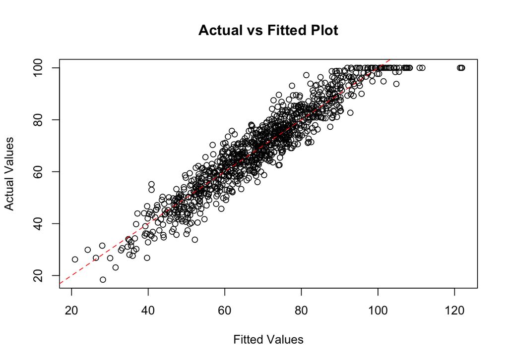

```r
plot(final_mod$fitted, studentData$exam_score,
     main = "Actual vs Fitted Plot",
     xlab = "Fitted Values",
     ylab = "Actual Values")
abline(a = 0, b = 1, col = "red", lty = 2)
```

### Normality of Residuals

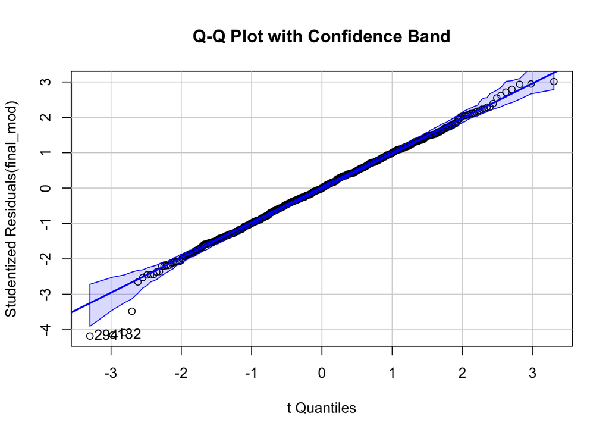

```
## [1] 132 294
```

```r
library(car)
qqPlot(final_mod, main = "Q-Q Plot with Confidence Band")
```

```r
# Shapiro-Wilk Test
shapiro.test(residuals(final_mod))
```

```
##
##  Shapiro-Wilk normality test
##
## data:  residuals(final_mod)
## W = 0.99523, p-value = 0.003196
```

### Homoscedasticity (Constant Variance of Residuals)

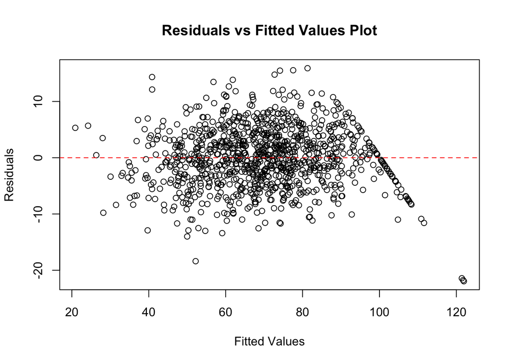

```r
plot(final_mod$fitted.values, final_mod$residuals,
     main = "Residuals vs Fitted Values Plot",
     xlab = "Fitted Values",
     ylab = "Residuals")
abline(h = 0, col = "red", lty = 2)
```

```r
# Breusch-Pagan Test
library(lmtest)
bptest(final_mod)
```

```
##
##  studentized Breusch-Pagan test
##
## data:  final_mod
## BP = 5.7464, df = 7, p-value = 0.5697
```

### Independence of Observations

#### Multicollinearity Assessment

```r
library(car)
vif(final_mod)
```

```
##   study_hours_per_day    social_media_hours         netflix_hours
##              1.003629              1.003859              1.001235
## attendance_percentage           sleep_hours    exercise_frequency
##              1.002867              1.001751              1.002650
##  mental_health_rating
##              1.000470
```

### Initial Overall Assessment of (Untransformed) Linear Model Assumptions

Linearity assumption: The fitted vs actual values plot overall shows a pretty linear relationship, thus satisfying this assumption.

Normality of residuals assumption: The QQ plot shows some points at the bottom end of the plot outside of the confidence band. In addition, a Shapiro-Wilk test of the residuals results in a p-value of 0.003196, leading to rejection of the null hypothesis of normality of the residuals at an alpha significance level of 0.05, in favor of the alternative hypothesis that the residuals are not normally distributed. This assumption is thus violated and will be addressed (see section below).

Homoscedasticity assumption: The residuals vs fitted plot depicts that the spread of residuals narrows at higher fitted values, showing a visible pattern (particularly towards the right side). This suggests non-constant variance. However, the Breusch-Pagan Test resulted in a p-value of 0.5697. As such, we fail to reject the null hypothesis of homoscedasticity at the alpha = 0.05 significance level. Overall, based on the formal Breusch-Pagan Test, the homoscedasticity assumption is determined to be met.

Multicollinearity assessment: The variance inflation factor for each predictor in the model is around 1, suggesting that there is no multicollinearity between predictors.

## Assumption Violation Handling

### Addressing Violation of the Normality of Residuals Assumption

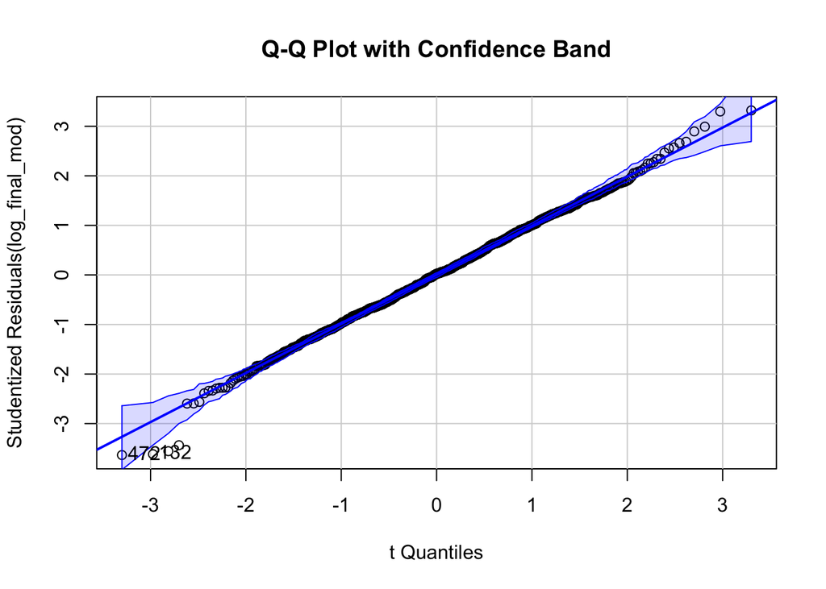

```
## [1] 132 472
```

```r
# Documenting Approach to Violation

#Transformation of covariate
log_final_mod <- lm(exam_score ~ study_hours_per_day + social_media_hours +
    netflix_hours + attendance_percentage + sleep_hours + exercise_frequency +
  log(mental_health_rating), data = studentData)

#Re-assessing normality of residuals assumption
qqPlot(log_final_mod, main = "Q-Q Plot with Confidence Band")
```

```r
# Shapiro-Wilk Test
shapiro.test(residuals(log_final_mod))
```

```
##
##  Shapiro-Wilk normality test
##
## data:  residuals(log_final_mod)
## W = 0.99778, p-value = 0.2025
```

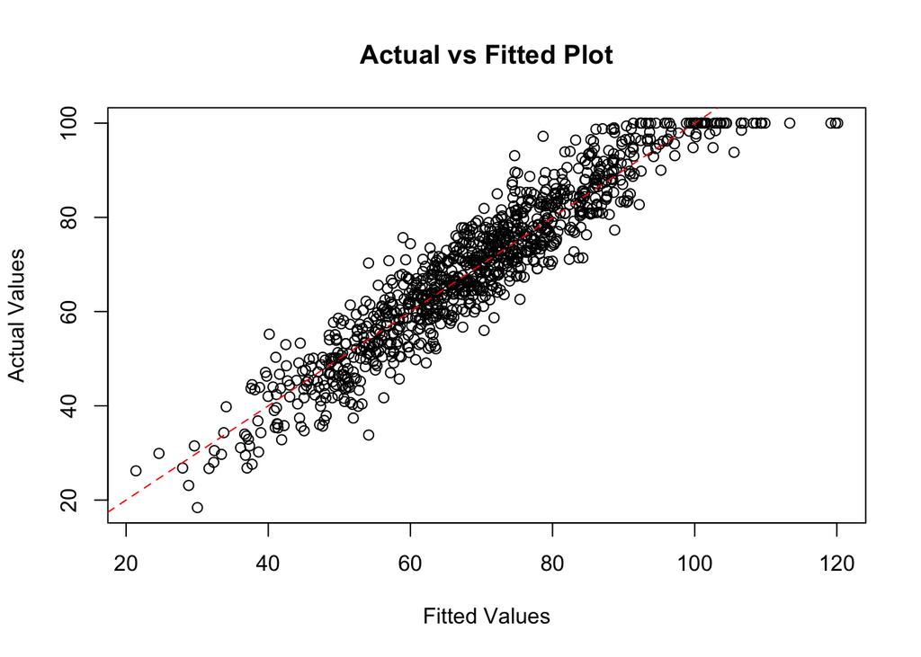

```r
# Re-assessing all other assumptions / comparing models after correction

# Linearity assumption
plot(log_final_mod$fitted, studentData$exam_score,
     main = "Actual vs Fitted Plot",
     xlab = "Fitted Values",
     ylab = "Actual Values")
abline(a = 0, b = 1, col = "red", lty = 2)
```

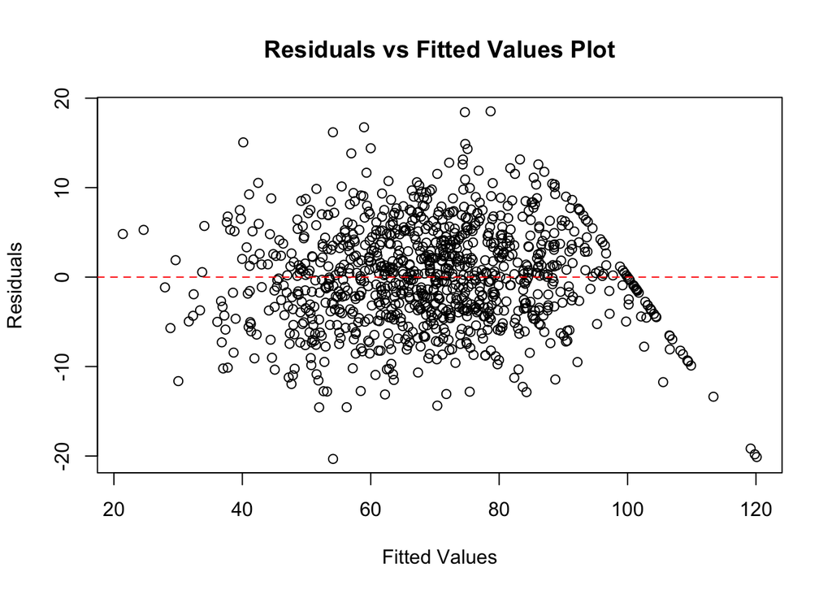

```r
# Homoscedasticity (constant variance of residuals)
plot(log_final_mod$fitted.values, log_final_mod$residuals,
     main = "Residuals vs Fitted Values Plot",
     xlab = "Fitted Values",
     ylab = "Residuals")
abline(h = 0, col = "red", lty = 2)
```

```r
# Breusch-Pagan Test
bptest(log_final_mod)
```

```
##
##  studentized Breusch-Pagan test
##
## data:  log_final_mod
## BP = 3.8051, df = 7, p-value = 0.8019
```

```r
# Multicollinearity
vif(log_final_mod)
```

```
##       study_hours_per_day        social_media_hours             netflix_hours
##                  1.003724                  1.003945                  1.001212
##     attendance_percentage               sleep_hours        exercise_frequency
##                  1.002858                  1.001981                  1.002684
## log(mental_health_rating)
##                  1.000867
```

### Overall Assessment of Transformed Linear Model Assumptions

Linearity assumption: The fitted vs actual values plot overall continues to show an overall fairly linear relationship, thus satisfying this assumption.

Normality of residuals assumption: The QQ plot shows nearly all of the points within the confidence band. In addition, a Shapiro-Wilk test of the residuals results in a p-value of 0.2025, leading to failure of rejecting the null hypothesis of normality at an alpha significance level of 0.05. This assumption is now met.

Homoscedasticity assumption: The residuals vs fitted plot continues to show that the spread of residuals narrows at higher fitted values, with the same visible pattern particularly towards the right side. This again potentially suggests non-constant variance. However, the Breusch-Pagan Test resulted in a p-value of 0.8019. As such, we fail to reject the null hypothesis of homoscedasticity at the alpha = 0.05 significance level. Overall, based on the formal Breusch-Pagan Test, the homoscedasticity assumption is met.

Independence of observations assumption: See previous answer as this continues to be the same.

Multicollinearity assessment: The variance inflation factor for each predictor in the model, with the newly transformed covariate, continues to be around 1, suggesting no multicollinearity between predictors.

```r
# Comparing model performance after correction

BIC(final_mod) # initial, untransformed model
```

```
## [1] 6238.967
```

```r
BIC(log_final_mod) #transformed model
```

```
## [1] 6353.535
```

```r
# Note: the above method for calculating BIC is slightly different than the method used in step-wise selection; as long as BIC values are derived from the same method when comparing models, the practical results should be the same

#summary of transformed model
summary(log_final_mod)
```

```
##
## Call:
## lm(formula = exam_score ~ study_hours_per_day + social_media_hours +
##     netflix_hours + attendance_percentage + sleep_hours + exercise_frequency +
##     log(mental_health_rating), data = studentData)
##
## Residuals:
##      Min       1Q   Median       3Q      Max
## -20.3260  -3.7339   0.1256   3.8321  18.5305
##
## Coefficients:
##                           Estimate Std. Error t value Pr(>|t|)
## (Intercept)                5.23510    2.01497   2.598  0.00951 **
## study_hours_per_day        9.59881    0.12181  78.799  < 2e-16 ***
## social_media_hours        -2.65150    0.15263 -17.372  < 2e-16 ***
## netflix_hours             -2.26688    0.16622 -13.638  < 2e-16 ***
## attendance_percentage      0.14396    0.01903   7.565 8.81e-14 ***
## sleep_hours                2.04594    0.14577  14.035  < 2e-16 ***
## exercise_frequency         1.43624    0.08830  16.266  < 2e-16 ***
## log(mental_health_rating)  7.55826    0.25808  29.286  < 2e-16 ***
## ---
## Signif. codes:  0 '***' 0.001 '**' 0.01 '*' 0.05 '.' 0.1 ' ' 1
##
## Residual standard error: 5.645 on 992 degrees of freedom
## Multiple R-squared:  0.8891, Adjusted R-squared:  0.8883
## F-statistic:  1136 on 7 and 992 DF,  p-value: < 2.2e-16
```

```r
#K-fold cross validation of transformed model

# Setting up 5-fold cross-validation
control2 <- trainControl(method = "cv", number = 5)

# Fitting selected model with cross-validation
cv_model2 <- train(
  exam_score ~ study_hours_per_day + social_media_hours +
    netflix_hours + attendance_percentage + sleep_hours +
    exercise_frequency + log(mental_health_rating),
  data = studentData,
  method = "lm",
  trControl = control2
)

# Results
cv_model2
```

```
## Linear Regression
##
## 1000 samples
##    7 predictor
##
## No pre-processing
## Resampling: Cross-Validated (5 fold)
## Summary of sample sizes: 800, 800, 800, 800, 800
## Resampling results:
##
##   RMSE     Rsquared   MAE
##   5.67624  0.8886772  4.520307
##
## Tuning parameter 'intercept' was held constant at a value of TRUE
```

# Results

## Feature Impact Analysis

### Quantifying and Interpreting the Impact of Each Feature on the Target (Using the Transformed Model)

Note: all covariates are significant in the final transformed model, meaning that each covariate has a significant association with final exam score when controlling for all other covariates. In other words, since the p-value for each covariate is less than the alpha = 0.05 significance level, the null hypothesis that each respective coefficient is zero is rejected, in favor of the alternative hypothesis that each respective coefficient non-zero.

study_hours_per day: coefficient = 9.59, $p < 2 \times 10^{-16}$; interpretation: Given two observations whose study hours per day values differ by 1 unit (hour), the observation with the larger study hours per day value will have an expected final exam score 9.59 units higher than the observation with the smaller study hours per day value.

log(mental_health_rating): coefficient = 7.56, $p < 2 \times 10^{-16}$; interpretation: Given two observations whose mental health rating values differ by 1%, the observation with the larger mental health rating value will have an expected final exam score 0.075 units (log(1.01)*7.56 units) higher than the observation with the smaller mental health rating value.

social_media_hours: coefficient = -2.65, $p < 2 \times 10^{-16}$; interpretation: Given two observations whose social media hours values differ by 1 unit (hour), the observation with the larger social media hours value will have an expected final exam score 2.65 units lower than the observation with the smaller social media hours value.

exercise_frequency: coefficient = 1.44, $p < 2 \times 10^{-16}$; interpretation: Given two observations whose exercise frequency values differ by 1 unit, the observation with the larger exercise frequency value will have an expected final exam score 1.44 units higher than the observation with the smaller exercise frequency value.

sleep_hours: coefficient = 2.05, $p < 2 \times 10^{-16}$; interpretation: Given two observations whose sleep hours per day values differ by 1 unit (hour), the observation with the larger sleep hours value will have an expected final exam score 2.05 units higher than the observation with the smaller sleep hours value.

netflix_hours: coefficient = -2.27, $p < 2 \times 10^{-16}$; interpretation: Given two observations whose Netflix hours values differ by 1 unit (hour), the observation with the larger Netflix hours value will have an expected final exam score -2.27 units lower than the observation with the smaller Netflix hours value.

attendance_percentage: coefficient = 0.14, $p < 8.81 \times 10^{-14}$; interpretation: Given two observations whose attendance percentage values differ by 1 unit (percent), the observation with the larger attendance percentage value will have an expected final exam score 0.14 units higher than the observation with the smaller attendance percentage value.

### Providing Confidence Intervals for Significant Coefficients

```r
# All coefficients of the model are significant
confint(log_final_mod, level = .95)
```

```
##                                2.5 %     97.5 %
## (Intercept)                1.2810134  9.1891837
## study_hours_per_day        9.3597677  9.8378504
## social_media_hours        -2.9510199 -2.3519795
## netflix_hours             -2.5930635 -1.9406961
## attendance_percentage      0.1066155  0.1812968
## sleep_hours                1.7598821  2.3320071
## exercise_frequency         1.2629676  1.6095061
## log(mental_health_rating)  7.0518080  8.0647121
```

# Discussion

This statistical analysis aimed to identify key demographic, lifestyle, environmental, and academic factors that predict final exam performance among students. Using multiple linear regression and cross-validation on a dataset with a sample size of 1,000 students, both the final untransformed model and transformed model achieved high predictive accuracy, with adjusted $R^2$ valyes of 0.90 and 0.89, respectively. This means the models explain approximately 90% and 89% of the variance in final exam scores, respectively. All predictors in the final transformed model were statistically significant. Model assumption validation assessment confirmed that the assumptions of linear regression were largely met for the initial untransformed model, with no significant evidence of heteroscedasticity or serious violations of linearity, independence, or multicollinearity. The residuals were not normally distributed; however, leading to the transformed model, which satisfied all assumptions of linear regression but had worse predictive performance. This reflects a bias–variance tradeoff: the transformed model may have lower bias, but increased variance (worse prediction). For the purpose of interpreting coefficients, hypothesis testing, statistical inference, and reporting valid p-values and confidence intervals, the transformed model is preferred since it meets all linear regression assumptions, even if it is slightly worse in predictive performance. However, the untransformed model remains valuable for predictive tasks, despite violating the normality assumption. The original, untransformed model is valuable for its better predictive performance, despite it violating the normality of residuals assumption. Both the untransformed model and the transformed model produced similar coefficient estimates for most predictors. The primary difference was observed in the transformed covariate, which showed altered effect size due to the log transformation. This suggests that the main findings are robust to model specification. Overall, providing both models allows for both inference and predictive insight, while acknowledging the strengths and limitations of each model. Since my primary goal is to understand how demographic, lifestyle, academic, and environmental factors jointly relate to final exam scores among students (vs prediction), the transformed model is more ideal to use for my interpretations.

Looking at the summary results from the transformed model, Unsurprisingly, the number of hours a student studies per day has the highest positive impact on exam score. Hours spent away from studying doing more leisurely activities such as watching Netflix or using social media had significant negative impact on exam score. Lifestyle factors such as sleep, exercise, and mental health also are meaningfully associated with improved scores, suggesting it is not only studying that affects exam performance. This highlights the importance of overall well-being on academic performance. Interestingly, attendance percentage had only a modest, (although significant) impact. This brings questions as to how students make up missed learning on days they do not attend classes, possibly through self-study or accessing class materials in other ways.

# Conclusion

The findings emphasize that academic performance is influenced by a range of factors, not only study habits. While studying more remains the most impactful strategy, lifestyle factors such as sleep, mental health, and exercise also play critical roles. In contrast, limiting distractions such as excessive media use may help improve outcomes. These insights can inform both students and educators in designing strategies to support academic performance through both behavioral and environmental interventions. Further research should be more transparent about data collection methods, assess other factors such as self-perceived test-taking ability, and consider longitudinal designs to better understand how these predictors influence academic performance over time.